# Aplicando conocimientos

## Objetivos

Aprender a graficar

## Recopilando datos

Descargué los datos proporcinados por https://github.com/GUIAD-COVID/datos-y-visualizaciones-GUIAD/blob/master/datos/estadisticasUY_porDepto_detalle.csv, del día 7 de abril de 2022, en formato csv.

### Cargando librerías

```r
library(readr)
library(knitr)
library(tidyverse)
```

### Cargando los datos a R

```r
data <- read_csv("data/estadisticas.csv",
                 col_select = -c("cantCasosNuevosCALC", "cantCasosNuevosAPP", "acumcasos"),
                 col_types=cols(fecha = col_date(format = "%d /%m /%Y")))
data <- rename(data, cantCasosNuevos=cantCasosNuevosConsolidado)
```

### Visualizando los datos

```r
head(data)
```

| fecha | departamento | enCurso | cantCasosNuevos | cantFallecidos | acumFallecidos | cantRecuperados | acumRecuperados |
| --- | --- | --- | --- | --- | --- | --- | --- |
| 2020-04-29 | Artigas(UY-AR) | 0 | 0 | 0 | 0 | 0 | 0 |
| 2020-04-29 | Canelones(UY-CA) | 17 | 0 | 0 | 2 | 0 | 66 |
| 2020-04-29 | Cerro Largo(UY-CL) | 0 | 0 | 0 | 0 | 0 | 0 |
| 2020-04-29 | Colonia(UY-CO) | 2 | 0 | 0 | 0 | 0 | 6 |
| 2020-04-29 | Durazno(UY-DU) | 0 | 0 | 0 | 0 | 1 | 1 |
| 2020-04-29 | Flores(UY-FS) | 0 | 0 | 0 | 0 | 0 | 1 |

Vemos que la columna de departamentos está escrita como “departamento(código)”, de esta forma no permite trabajarla bien, por lo que vamos a cambiar el nombre de “departamento(codigo)” a solo “departamento”

```r
dpts_old_names <- c("Artigas(UY-AR)", "Canelones(UY-CA)", "Cerro Largo(UY-CL)", "Colonia(UY-CO)", "Durazno(UY-DU)", "Flores(UY-FS)", "Florida(UY-FD)", "Lavalleja(UY-LA)", "Maldonado(UY-MA)", "Montevideo(UY-MO)", "Paysandú(UY-PA)", "Río Negro(UY-RN)", "Rivera(UY-RV)", "Rocha(UY-RO)", "Salto(UY-SA)", "San José(UY-SJ)", "Soriano(UY-SO)", "Tacuarembó(UY-TA)", "Treinta y Tres(UY-TT)")

dpts_new_names <- c("ARTIGAS", "CANELONES", "CERRO LARGO", "COLONIA", "DURAZNO", "FLORES", "FLORIDA", "LAVALLEJA", "MALDONADO", "MONTEVIDEO", "PAYSANDÚ", "RÍO NEGRO", "RIVERA", "ROCHA", "SALTO", "SAN JOSÉ", "SORIANO", "TACUAREMBÓ", "TREINTA Y TRES")

for (i in 1:length(dpts_new_names)) {
  data <- data %>%
    mutate(departamento = ifelse(departamento == dpts_old_names[i], dpts_new_names[i], departamento))
}
```

Visualizamos la nueva tabla:

```r
head(data)
```

| fecha | departamento | enCurso | cantCasosNuevos | cantFallecidos | acumFallecidos | cantRecuperados | acumRecuperados |
| --- | --- | --- | --- | --- | --- | --- | --- |
| 2020-04-29 | ARTIGAS | 0 | 0 | 0 | 0 | 0 | 0 |
| 2020-04-29 | CANELONES | 17 | 0 | 0 | 2 | 0 | 66 |
| 2020-04-29 | CERRO LARGO | 0 | 0 | 0 | 0 | 0 | 0 |
| 2020-04-29 | COLONIA | 2 | 0 | 0 | 0 | 0 | 6 |
| 2020-04-29 | DURAZNO | 0 | 0 | 0 | 0 | 1 | 1 |
| 2020-04-29 | FLORES | 0 | 0 | 0 | 0 | 0 | 1 |

Grafico para visualizar la cantidad de casos nuevo, seleccionado un departamento, en el ejemplo se puede ver a Canelones.

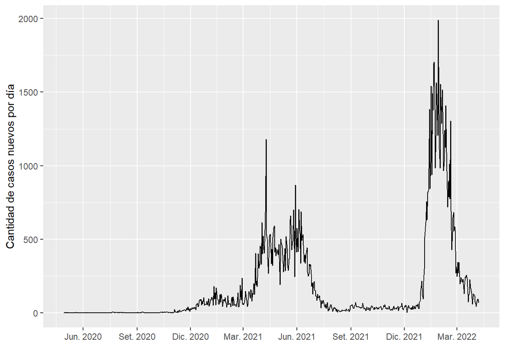

```r
data %>%
  filter(departamento == "CANELONES") %>%
  ggplot(aes(x=fecha, y=cantCasosNuevos)) +
    geom_line() +
    scale_x_date(date_breaks = "3 month", date_labels =  "%b %Y")+
    xlab("") + ylab("Cantidad de casos nuevos por día")
```

Seguimos visualizando el máximo histórico de casos nuevos en un día por departamentos. Primero se puede ver el código que utilizo para obtener el máximo de casos nuevos por departamento: (Estoy seguro de que esto se puede hacer de otra forma mucho más fácil)

```r
data %>%
  filter(departamento == "CANELONES") %>%
  filter(cantCasosNuevos == max(cantCasosNuevos))
```

| fecha | departamento | enCurso | cantCasosNuevos | cantFallecidos | acumFallecidos | cantRecuperados | acumRecuperados |
| --- | --- | --- | --- | --- | --- | --- | --- |
| 2022-01-28 | CANELONES | 9536 | 1990 | 4 | 759 | 1587 | 82385 |

Luego tengo que generar otra tabla donde almacenar esa información.

```r
max_cases_per_dept <- data.frame(matrix(ncol = 8, nrow=0))
columns_of_data <- names(data)
colnames(max_cases_per_dept) <- columns_of_data
max_cases_per_dept <- as_tibble(max_cases_per_dept)

dpts <- as.list(distinct(data, departamento))$departamento

for (x in 1:length(dpts)) {
  a <- data %>%
    filter(departamento == (dpts[x])) %>%
    filter(cantCasosNuevos == max(cantCasosNuevos))
  max_cases_per_dept <- rbind(max_cases_per_dept, a)
}

col_order <- c("departamento", "cantCasosNuevos", "enCurso", "cantFallecidos", "acumFallecidos", "cantRecuperados", "acumRecuperados", "fecha")
max_cases_per_dept <- max_cases_per_dept[, col_order]
```

### Caminos más cortos y faciles

Navegando en internet me doy cuenta que estaba complicando todo…

Así de facil se puede graficar los casos nuevos por día para todo Uruguay.

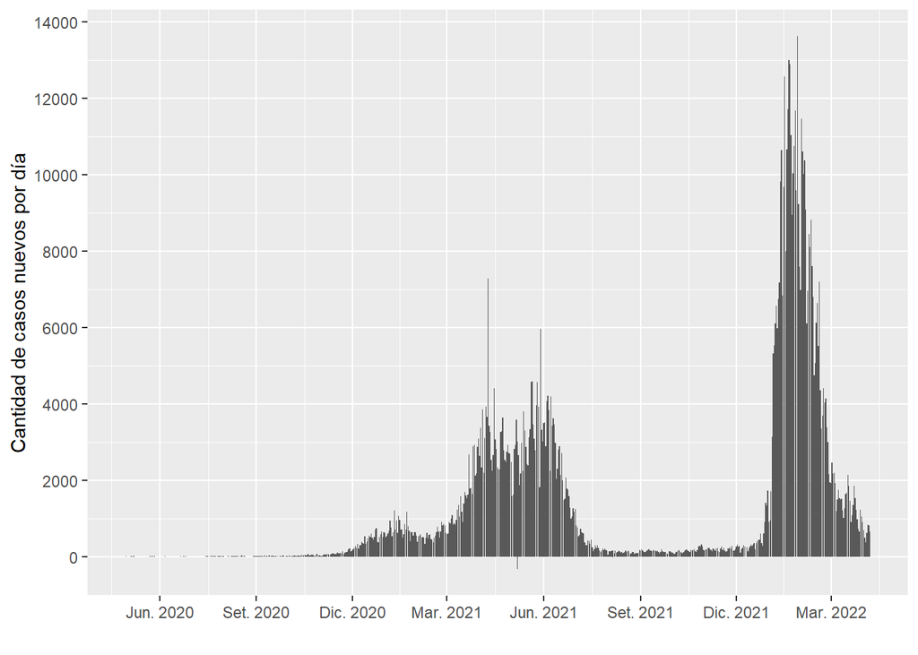

```r
data %>%
  ggplot(aes(x= fecha, y=cantCasosNuevos))+
    geom_bar(stat = 'identity')+
    scale_x_date(date_breaks = "3 month", date_labels =  "%b %Y")+
    xlab("") + ylab("Cantidad de casos nuevos por día") +
    scale_y_continuous(breaks=seq(0, 14000, by=2000))
```

Así para un departamento dado:

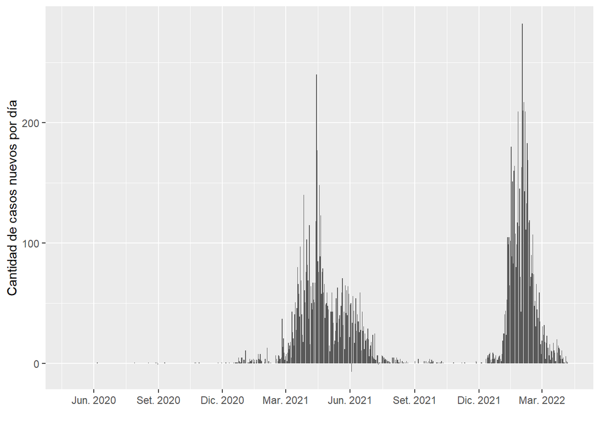

```r
data %>%
  filter(departamento=="RÍO NEGRO") %>%
  ggplot(aes(x= fecha, y=cantCasosNuevos))+
    geom_bar(stat = 'identity') +
    scale_x_date(date_breaks = "3 month", date_labels =  "%b %Y")+
    xlab("") + ylab("Cantidad de casos nuevos por día")
```

Y de esta forma puedo agrupar la tabla por departamentos, para luego buscar el top 1 de casos nuevos en cada departamento.

```r
max_cases_per_dept_vEasy <- data %>% group_by(departamento) %>% top_n(n=1, wt = cantCasosNuevos)
```

Ahora lo grafico:

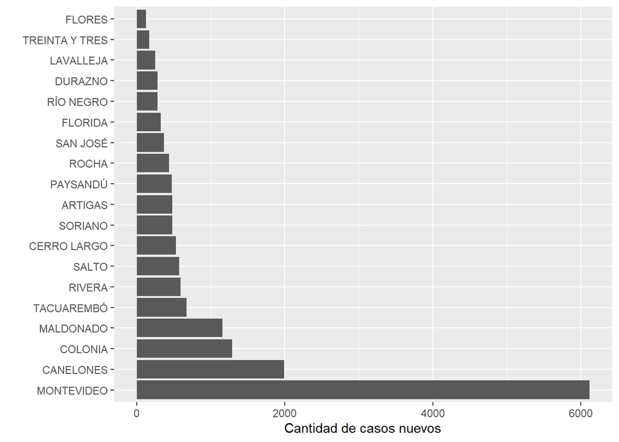

```r
max_cases_per_dept_vEasy %>%
  ggplot(aes(reorder(departamento, -cantCasosNuevos), cantCasosNuevos)) +
    geom_bar(stat = "identity") +
    coord_flip() +
    xlab("") + ylab("Cantidad de casos nuevos")
```

## Pasando datos a QGis

```r
to_export <- max_cases_per_dept_vEasy %>%
  select(departamento, cantCasosNuevos) %>%
  write_csv("max_cases_per_dept.csv")
```

Allí usando el el .shp de los departamentos de uruguay, uní el csv exportando anteriormente a la tabla de atributos de los departamentos. Luego categoricé los departamentos en base a la cantidad de casos nuevos históricos y los coloré.

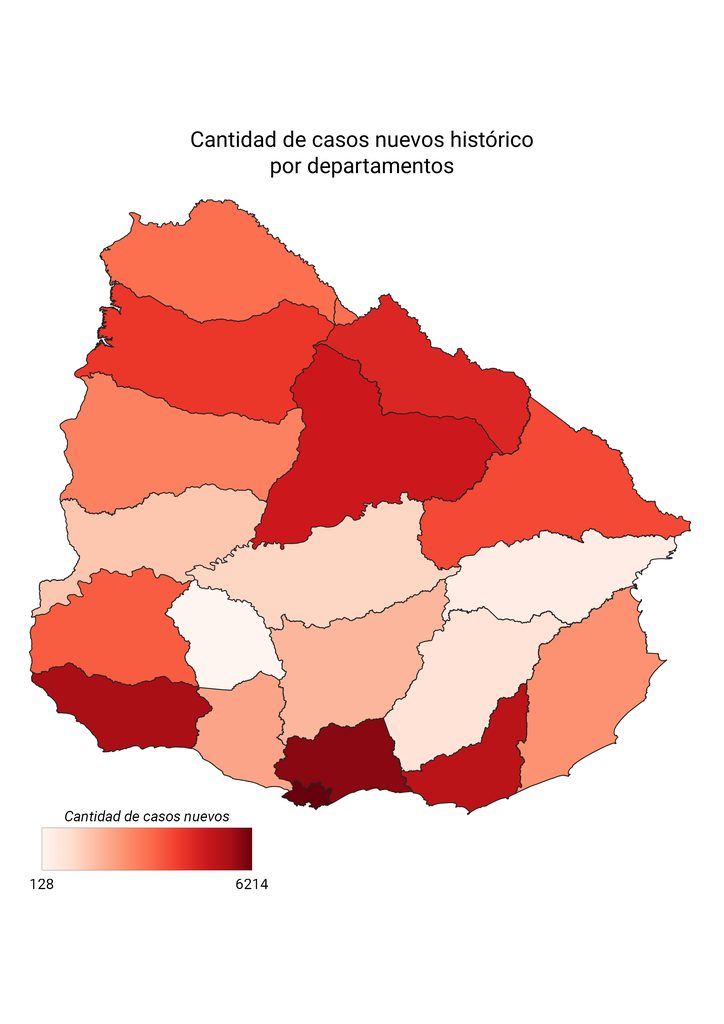